# IODS course project

### Fitting regression models

### explanatory variables: attitude, stra, surf

```r
model1 <- lm(points ~ attitude + stra + surf, data = ex2)
summary(model1)
```

```
##
## Call:
## lm(formula = points ~ attitude + stra + surf, data = ex2)
##
## Residuals:
##      Min       1Q   Median       3Q      Max
## -17.1550  -3.4346   0.5156   3.6401  10.8952
##
## Coefficients:
##             Estimate Std. Error t value Pr(>|t|)
## (Intercept)  11.0171     3.6837   2.991  0.00322 **
## attitude      3.3952     0.5741   5.913 1.93e-08 ***
## stra          0.8531     0.5416   1.575  0.11716
## surf         -0.5861     0.8014  -0.731  0.46563
## ---
## Signif. codes:  0 '***' 0.001 '**' 0.01 '*' 0.05 '.' 0.1 ' ' 1
##
## Residual standard error: 5.296 on 162 degrees of freedom
## Multiple R-squared:  0.2074, Adjusted R-squared:  0.1927
## F-statistic: 14.13 on 3 and 162 DF,  p-value: 3.156e-08
```

```r
model2 <- lm(points ~ attitude + stra, data = ex2)
summary(model2)
```

```
##
## Call:
## lm(formula = points ~ attitude + stra, data = ex2)
##
## Residuals:
##      Min       1Q   Median       3Q      Max
## -17.6436  -3.3113   0.5575   3.7928  10.9295
##
## Coefficients:
##             Estimate Std. Error t value Pr(>|t|)
## (Intercept)   8.9729     2.3959   3.745  0.00025 ***
## attitude      3.4658     0.5652   6.132 6.31e-09 ***
## stra          0.9137     0.5345   1.709  0.08927 .
## ---
## Signif. codes:  0 '***' 0.001 '**' 0.01 '*' 0.05 '.' 0.1 ' ' 1
##
## Residual standard error: 5.289 on 163 degrees of freedom
## Multiple R-squared:  0.2048, Adjusted R-squared:  0.1951
## F-statistic: 20.99 on 2 and 163 DF,  p-value: 7.734e-09
```

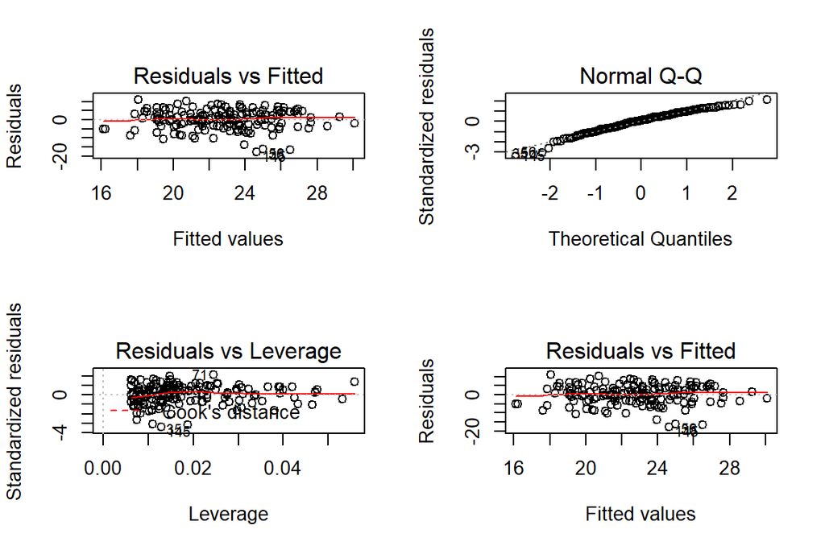

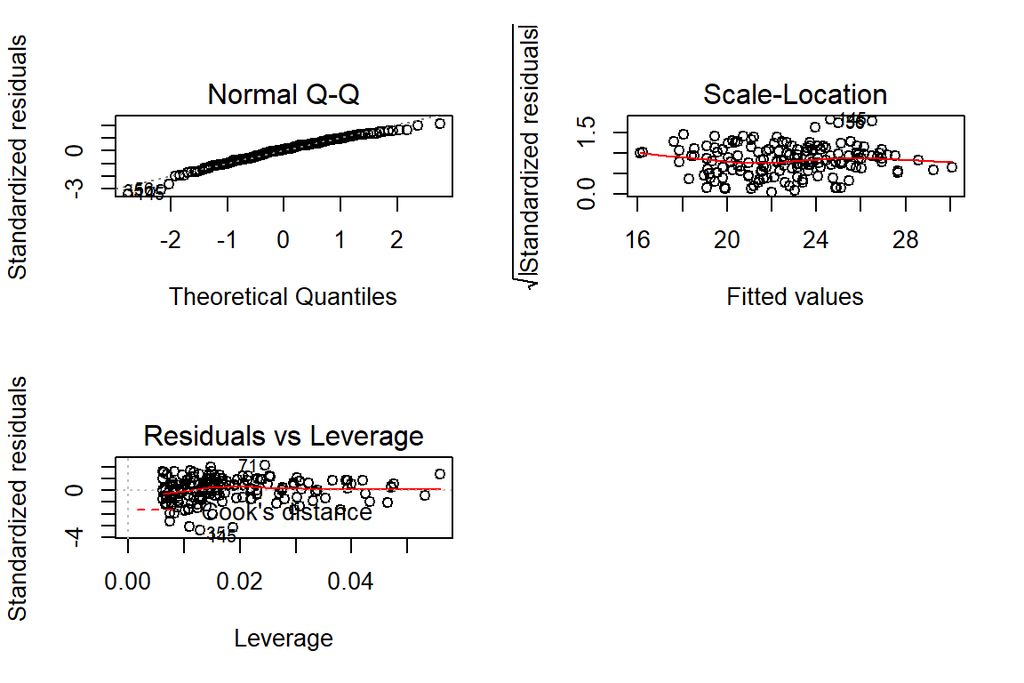

```r
par(mfrow = c(2,2))
plot(model2, which = c(1,2,5))
plot(model2)
```

# Logistic regression

## Data wrangling

https://github.com/shinyk0514/IODS-project/blob/master/create_alc.R

## Data analysis

### Task 2: Reading the data and printing out the names of variables

```r
alc <- read.csv("C:\\Users\\Young Shin\\Documents\\IODS-project\\data\\alc.csv", sep = ",")
colnames(alc)
```

```
##  [1] "X"          "school"     "sex"        "age"        "address"
##  [6] "famsize"    "Pstatus"    "Medu"       "Fedu"       "Mjob"
## [11] "Fjob"       "reason"     "nursery"    "internet"   "guardian"
## [16] "traveltime" "studytime"  "failures"   "schoolsup"  "famsup"
## [21] "paid"       "activities" "higher"     "romantic"   "famrel"
## [26] "freetime"   "goout"      "Dalc"       "Walc"       "health"
## [31] "absences"   "G1"         "G2"         "G3"         "alc_use"
## [36] "high_use"
```

- The dataset provides the information on alcohol consumption of the students who attended both courses of mathematics and Portuguese language. It has 382 observations of 36 variables as shown above.*

### Task 3: Choosing four variables and setting up hypetheses

I am interested in the variables, age, Pstatus, higher and famrel. Thus, my hypotheses are as follows: H1: Age increases the probability that a student becomes a heavy alcohol consumer. H2: Living with parent decreases the probability that a student becomes a heavy alcohol consumer. H3: Willingness to take higher education decreases the probability that a student becomes a heavy alcohol consumer. H4: The better family relationships are, the less the probability that a student becomes a heavy alcohol consumer.

### Task 4: Exploring the chosen variables

#### Cross-tabulations

```r
library(dplyr); library(ggplot2)
alc %>% group_by(age, high_use) %>% summarise(count = n())
```

```
## # A tibble: 12 x 3
## # Groups:   age [7]
##      age high_use count
##    <int> <lgl>    <int>
##  1    15 FALSE       63
##  2    15 TRUE        18
##  3    16 FALSE       79
##  4    16 TRUE        28
##  5    17 FALSE       64
##  6    17 TRUE        36
##  7    18 FALSE       54
##  8    18 TRUE        27
##  9    19 FALSE        7
## 10    19 TRUE         4
## 11    20 FALSE        1
## 12    22 TRUE         1
```

```r
alc %>% group_by(Pstatus, high_use) %>% summarise(count = n())
```

```
## # A tibble: 4 x 3
## # Groups:   Pstatus [2]
##   Pstatus high_use count
##   <fct>   <lgl>    <int>
## 1 A       FALSE       26
## 2 A       TRUE        12
## 3 T       FALSE      242
## 4 T       TRUE       102
```

```r
alc %>% group_by(higher, high_use) %>% summarise(count = n())
```

```
## # A tibble: 4 x 3
## # Groups:   higher [2]
##   higher high_use count
##   <fct>  <lgl>    <int>
## 1 no     FALSE        9
## 2 no     TRUE         9
## 3 yes    FALSE      259
## 4 yes    TRUE       105
```

```r
alc %>% group_by(famrel, high_use) %>% summarise(count = n())
```

```
## # A tibble: 10 x 3
## # Groups:   famrel [5]
##    famrel high_use count
##     <int> <lgl>    <int>
##  1      1 FALSE        6
##  2      1 TRUE         2
##  3      2 FALSE       10
##  4      2 TRUE         9
##  5      3 FALSE       39
##  6      3 TRUE        25
##  7      4 FALSE      135
##  8      4 TRUE        54
##  9      5 FALSE       78
## 10      5 TRUE        24
```

#### Bar plots

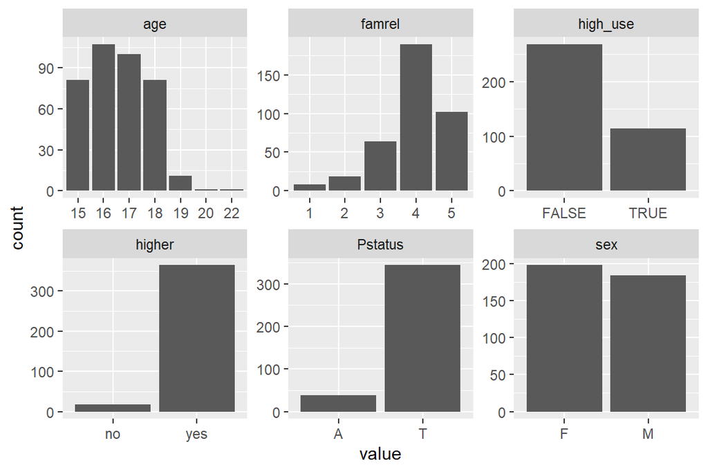

```r
library(tidyr)
chosen_var <- c("age", "sex", "Pstatus", "higher", "high_use", "famrel")
alc <- dplyr::select(alc, one_of(chosen_var))
gather(alc) %>% ggplot(aes(value)) + facet_wrap("key", scales = "free") + geom_bar()
```

#### Box plots

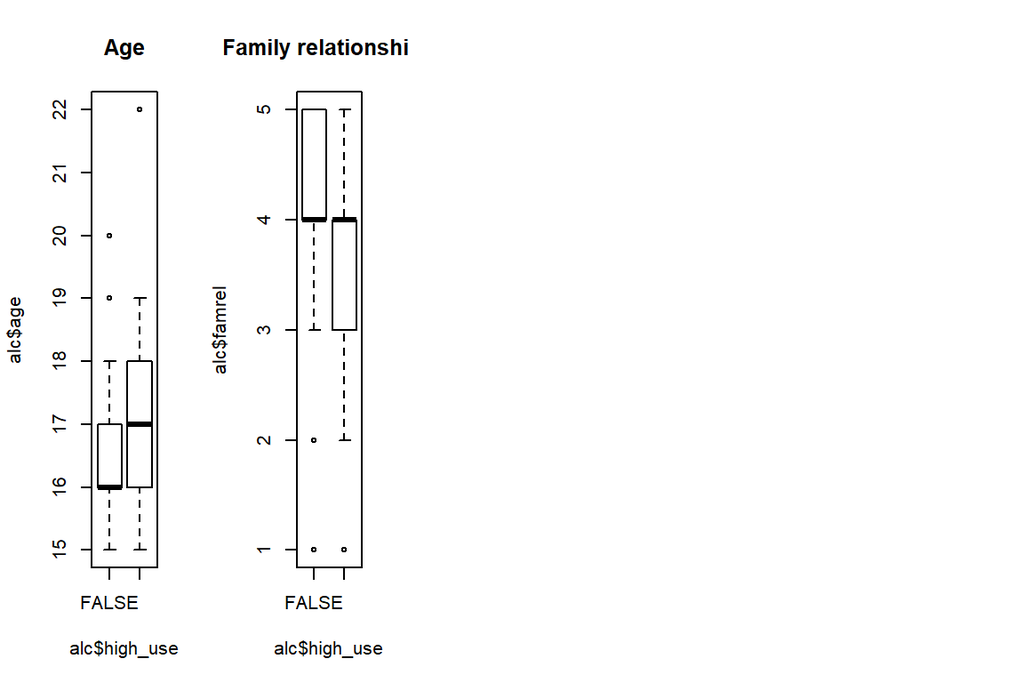

```r
library(tidyr); library(dplyr); library(ggplot2); library(corrplot); library(boot)
par(mfrow=c(1,5))
boxplot(alc$age~alc$high_use, main="Age")
boxplot(alc$famrel~alc$high_use, main="Family relationships")
```

#### Interpretation

According to the tabulations and plots above, it is probalbe that age would increase the possibility that the variables, age, willingness to take higher education and family relations would be associated with high level of alcohol consumption. However, it does not seem that parent’s cohabitation has an association with alcohol consumption.

### Task 5: Fitting logistic regression

#### Model

```r
m <- glm(alc$high_use ~ alc$age + alc$higher + alc$Pstatus + alc$famrel, data = alc, family = "binomial")
```

#### Summary

```r
summary(m)
```

```
##
## Call:
## glm(formula = alc$high_use ~ alc$age + alc$higher + alc$Pstatus +
##     alc$famrel, family = "binomial", data = alc)
##
## Deviance Residuals:
##     Min       1Q   Median       3Q      Max
## -1.3769  -0.8401  -0.7474   1.3488   1.8527
##
## Coefficients:
##               Estimate Std. Error z value Pr(>|z|)
## (Intercept)   -2.28068    1.88197  -1.212   0.2256
## alc$age        0.19274    0.09973   1.933   0.0533 .
## alc$higheryes -0.65922    0.50396  -1.308   0.1908
## alc$PstatusT  -0.10533    0.37615  -0.280   0.7795
## alc$famrel    -0.27280    0.12287  -2.220   0.0264 *
## ---
## Signif. codes:  0 '***' 0.001 '**' 0.01 '*' 0.05 '.' 0.1 ' ' 1
##
## (Dispersion parameter for binomial family taken to be 1)
##
##     Null deviance: 465.68  on 381  degrees of freedom
## Residual deviance: 453.91  on 377  degrees of freedom
## AIC: 463.91
##
## Number of Fisher Scoring iterations: 4
```

#### Coefficients, OR and confidenc intervals

```r
coef(m)
```

```
##   (Intercept)       alc$age alc$higheryes  alc$PstatusT    alc$famrel
##    -2.2806756     0.1927373    -0.6592188    -0.1053332    -0.2727957
```

```r
OR <- coef(m) %>% exp
CI <- confint(m) %>% exp
cbind(OR, CI)
```

```
##                      OR       2.5 %    97.5 %
## (Intercept)   0.1022151 0.002503272 4.0749747
## alc$age       1.2125642 0.998017351 1.4769556
## alc$higheryes 0.5172553 0.190339904 1.4116753
## alc$PstatusT  0.9000246 0.438801797 1.9405745
## alc$famrel    0.7612483 0.597334264 0.9687199
```

### Task 6: Prediction

#### Probabilities

```r
probabilities <- predict(m, type = "response")
```

#### adding the predicted probabilities to ‘alc’

```r
alc <- mutate(alc, probability = probabilities)
```

#### using the probabilities to make a prediction of high_use

```r
alc <- mutate(alc, prediction = probability > 0.5)
```

#### seeing the last ten original classes, predicted probabilities, and class predictions

```r
select(alc, age, higher, Pstatus, famrel, probability, prediction) %>% tail(10)
```

```
##     age higher Pstatus famrel probability prediction
## 373  19    yes       T      4   0.3835750      FALSE
## 374  18    yes       T      5   0.2809136      FALSE
## 375  18    yes       T      5   0.2809136      FALSE
## 376  18    yes       T      4   0.3391378      FALSE
## 377  19    yes       T      5   0.3214323      FALSE
## 378  18    yes       T      4   0.3391378      FALSE
## 379  18    yes       T      2   0.4696505      FALSE
## 380  18    yes       T      1   0.5377402       TRUE
## 381  17    yes       T      2   0.4220692      FALSE
## 382  18    yes       T      4   0.3391378      FALSE
```

#### tabulating the target variable versus the predictions

```r
table(high_use = alc$high_use, prediction = alc$prediction)
```

```
##         prediction
## high_use FALSE TRUE
##    FALSE   261    7
##    TRUE    110    4
```

#### initializing a plot of ‘high_use’ versus ‘probability’ in ‘alc’

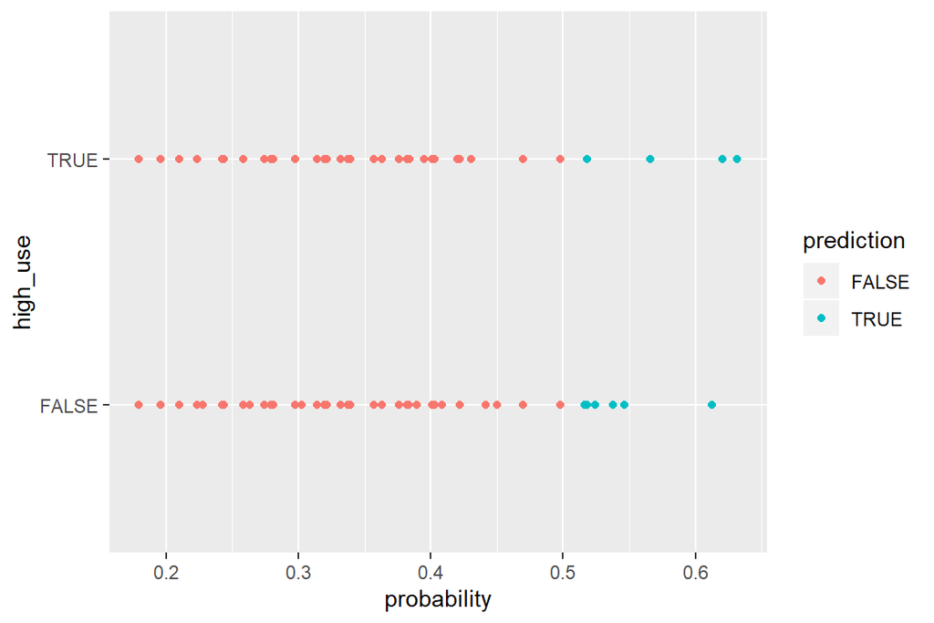

```r
g <- ggplot(alc, aes(x = probability, y = high_use, col = prediction))
g + geom_point()
```

#### defining a loss function

```r
loss_func <- function(class, prob) {
  n_wrong <- abs(class - prob) > 0.5
  mean(n_wrong)
}
```

#### calling loss_func to compute the average number of wrong predictions in the (training) data

```r
loss_func(class = alc$high_use, prob = alc$probability)
```

```
## [1] 0.3062827
```

# Clustering and classification

## Data analysis

### Loading and exploring the Boston data

```r
library(MASS)
data("Boston")
str(Boston)
```

```
## 'data.frame':    506 obs. of  14 variables:
##  $ crim   : num  0.00632 0.02731 0.02729 0.03237 0.06905 ...
##  $ zn     : num  18 0 0 0 0 0 12.5 12.5 12.5 12.5 ...
##  $ indus  : num  2.31 7.07 7.07 2.18 2.18 2.18 7.87 7.87 7.87 7.87 ...
##  $ chas   : int  0 0 0 0 0 0 0 0 0 0 ...
##  $ nox    : num  0.538 0.469 0.469 0.458 0.458 0.458 0.524 0.524 0.524 0.524 ...
##  $ rm     : num  6.58 6.42 7.18 7 7.15 ...
##  $ age    : num  65.2 78.9 61.1 45.8 54.2 58.7 66.6 96.1 100 85.9 ...
##  $ dis    : num  4.09 4.97 4.97 6.06 6.06 ...
##  $ rad    : int  1 2 2 3 3 3 5 5 5 5 ...
##  $ tax    : num  296 242 242 222 222 222 311 311 311 311 ...
##  $ ptratio: num  15.3 17.8 17.8 18.7 18.7 18.7 15.2 15.2 15.2 15.2 ...
##  $ black  : num  397 397 393 395 397 ...
##  $ lstat  : num  4.98 9.14 4.03 2.94 5.33 ...
##  $ medv   : num  24 21.6 34.7 33.4 36.2 28.7 22.9 27.1 16.5 18.9 ...
```

```r
summary(Boston)
```

```
##       crim                zn             indus            chas
##  Min.   : 0.00632   Min.   :  0.00   Min.   : 0.46   Min.   :0.00000
##  1st Qu.: 0.08204   1st Qu.:  0.00   1st Qu.: 5.19   1st Qu.:0.00000
##  Median : 0.25651   Median :  0.00   Median : 9.69   Median :0.00000
##  Mean   : 3.61352   Mean   : 11.36   Mean   :11.14   Mean   :0.06917
##  3rd Qu.: 3.67708   3rd Qu.: 12.50   3rd Qu.:18.10   3rd Qu.:0.00000
##  Max.   :88.97620   Max.   :100.00   Max.   :27.74   Max.   :1.00000
##       nox               rm             age              dis
##  Min.   :0.3850   Min.   :3.561   Min.   :  2.90   Min.   : 1.130
##  1st Qu.:0.4490   1st Qu.:5.886   1st Qu.: 45.02   1st Qu.: 2.100
##  Median :0.5380   Median :6.208   Median : 77.50   Median : 3.207
##  Mean   :0.5547   Mean   :6.285   Mean   : 68.57   Mean   : 3.795
##  3rd Qu.:0.6240   3rd Qu.:6.623   3rd Qu.: 94.08   3rd Qu.: 5.188
##  Max.   :0.8710   Max.   :8.780   Max.   :100.00   Max.   :12.127
##       rad              tax           ptratio          black
##  Min.   : 1.000   Min.   :187.0   Min.   :12.60   Min.   :  0.32
##  1st Qu.: 4.000   1st Qu.:279.0   1st Qu.:17.40   1st Qu.:375.38
##  Median : 5.000   Median :330.0   Median :19.05   Median :391.44
##  Mean   : 9.549   Mean   :408.2   Mean   :18.46   Mean   :356.67
##  3rd Qu.:24.000   3rd Qu.:666.0   3rd Qu.:20.20   3rd Qu.:396.23
##  Max.   :24.000   Max.   :711.0   Max.   :22.00   Max.   :396.90
##      lstat            medv
##  Min.   : 1.73   Min.   : 5.00
##  1st Qu.: 6.95   1st Qu.:17.02
##  Median :11.36   Median :21.20
##  Mean   :12.65   Mean   :22.53
##  3rd Qu.:16.95   3rd Qu.:25.00
##  Max.   :37.97   Max.   :50.00
```

*Boston dataset consists of 506 observations of 14 variables.*